# Procesamiento de datos con tidyverse

Ayudantía 02 · FAGOB 2026

Cristóbal Mejías · Facultad de Gobierno

Métodos Cuantitativos para la Administración Pública

marzo de 2026

## ¿Qué veremos hoy?

1. Repaso y carga de datos
2. Tipos de variables en R
3. El pipe `|>`
4. `select()` y `filter()`
5. `mutate()`: recodificar
6. Valores perdidos (NA)
7. Crear categorías
8. Guardar la base procesada

**Al final de la sesión**

Tendrás una base limpia, procesada y guardada, lista para analizar en la próxima ayudantía.

# Punto de partida

## ¿Qué hicimos en la AY-1?

- Creamos un **proyecto en R** con estructura IPO
- Cargamos datos con `read_csv()`
- Exploramos la CASEN con `dim()`, `glimpse()` y `count()`

Problema: los datos aún no están listos para analizar. Las variables tienen **códigos numéricos** en vez de etiquetas, hay **valores especiales** (-88, -99) y los tipos de dato no son los correctos.

## Paquetes de hoy

```r
pacman::p_load(
  tidyverse,     # manipulación de datos (dplyr, tidyr, readr...)
  haven,         # leer bases de Stata/SPSS (.dta, .sav)
  sjmisc,        # frecuencias y descriptivos (frq, descr)
  sjlabelled,    # etiquetas y valores perdidos (set_na)
  sjPlot,        # ver la base completa con etiquetas (view_df)
  naniar         # visualizar valores perdidos
)
```

## Cargar la base de datos

La cargamos directamente **desde GitHub**:

```r
casen <- read_dta("https://github.com/Cristobal-Mejias-G/metodos-cuantitativos-fagob/raw/main/datos/casen_fagob.dta")
```

Son **5.000 casos** y **16 variables** de la CASEN 2024. Al venir de Stata (`.dta`), las variables llegan como **`haven_labelled`**: números con etiquetas pegadas.

## Primera mirada

```r
view_df(casen)   # abre en el Viewer: variables, etiquetas y valores
```

```r
frq(casen$sexo)
```

```
Sexo (x) <numeric>
# total N=5000 valid N=5000 mean=1.53 sd=0.50

Value |  Label |    N | Raw % | Valid % | Cum. %
------------------------------------------------
    1 | Hombre | 2370 | 47.40 |   47.40 |  47.40
    2 |  Mujer | 2630 | 52.60 |   52.60 | 100.00
 <NA> |   <NA> |    0 |  0.00 |    <NA> |   <NA>
```

# Tipos de variables en R

## ¿Por qué importa el tipo de variable?

R necesita saber qué tipo de dato es una variable para hacer las operaciones, funciones y gráficos correctos.

```r
class(casen$sexo)
```

```
[1] "haven_labelled" "vctrs_vctr"     "double"
```

```r
class(casen$edad)
```

```
[1] "numeric"
```

| Lo que ves en `class()` | Qué significa | Qué hacer |
| --- | --- | --- |
| `numeric` / `double` | Número | Listo si tiene sentido matemático |
| `character` | Texto | Convertir a `factor` si es categórica |
| `factor` | Categorías con niveles | Listo |
| `haven_labelled` | Número con etiqueta (Stata/SPSS) | **Convertir a `factor` o a número** |

## ¿Qué es `haven_labelled`?

`"haven_labelled" "vctrs_vctr" "double"` se lee de abajo hacia arriba:

- **`double`**: en el fondo es un número (1, 2, 3…)
- **`haven_labelled`**: lleva las etiquetas “en la mochila”: el `1` sabe que significa “Hombre”

Dos caminos para trabajarlas:

```r
# Camino rápido: usar las etiquetas
# que ya trae la base
as_factor(casen$activ) |>
  head()
```

[output not shown]

El otro camino es quitar las etiquetas (`zap_labels()`) y recodificar con nuestras propias categorías. Es el que usaremos hoy.

# El pipe `|>`

## ¿Qué es el pipe?

`|>` significa: **“toma esto y pásalo a la siguiente función”**.

```r
x |> f()          # equivale a f(x)
x |> f() |> g()   # equivale a g(f(x))
```

**Sin pipe**

```r
datos <- select(casen, sexo, edad)
datos <- filter(datos, edad >= 18)
```

**Con pipe**

```r
datos <- casen |>
  select(sexo, edad) |>
  filter(edad >= 18)
```

Atajo: `Ctrl + Shift + M`. Para que escriba `|>` y no `%>%`: *Tools → Global Options → Code → Use native pipe operator*.

# `select()` y `filter()`

## `select()`: elegir y renombrar columnas

Los nombres de la CASEN son crípticos (`yoprcor`, `o10`…). Con `select()` elegimos variables y las renombramos con `nuevo = original`:

```r
casen_proc <- casen |>
  select(
    region, zona = area,                                  # identificación
    sexo, edad, estado_civil = ecivil,                    # demografía
    nivel_educ = educc, asiste_educ = e3,                 # educación
    actividad = activ, categ_ocup = o15,                  # trabajo
    horas_trab = o10, contrato = o19,
    ingreso = yoprcor, ingreso_pc = ypchtotcor,           # ingresos
    pobreza = pobreza_severa, pueblo_orig = pueblos_indigenas, lugar_nac
  ) |>
  mutate(across(everything(), haven::zap_labels))         # quitar etiquetas: todo a número
```

Escribimos `haven::zap_labels` porque `sjlabelled` tiene otra función con el mismo nombre que hace algo distinto. `paquete::función` le dice a R cuál usar.

## `filter()`: elegir filas

| Operador | Significado | Ejemplo |
| --- | --- | --- |
| `==` / `!=` | igual / distinto | `sexo == 1` |
| `>` `<` `>=` `<=` | comparaciones | `edad >= 60` |
| `&` / `\|` | y / o | `sexo == 2 & edad > 18` |
| `%in%` | pertenece a un conjunto | `region %in% c(13, 5)` |

```r
adultos <- casen_proc |>
  filter(edad > 18)

rm_valpo <- casen_proc |>
  filter(region %in% c(13, 5))

nrow(casen_proc)
```

```
[1] 5000
```

```r
nrow(adultos)
```

```
[1] 3882
```

# `mutate()`: recodificar

## Recodificar: de códigos a categorías

`mutate()` crea o modifica columnas. Con `factor()` asignamos a cada código su etiqueta y definimos el orden de las categorías:

```r
casen_proc <- casen_proc |>
  mutate(
    sexo = factor(sexo,
                  levels = c(1, 2),
                  labels = c("Hombre", "Mujer")),
    actividad = factor(actividad,
                       levels = c(1, 2, 3),
                       labels = c("Ocupado/a", "Desocupado/a", "Inactivo/a")),
    pobreza = factor(pobreza,
                     levels = c(1, 2, 3, 4),
                     labels = c("Pobreza severa", "Pobreza por ingresos",
                                "Pobreza multidimensional", "No pobre"))
  )
```

El orden de `labels` controla el orden en tablas y gráficos. El primer nivel será la categoría de referencia en regresiones.

## Verificar siempre

```r
frq(casen_proc$actividad)
```

```
x <categorical>
# total N=5000 valid N=4171 mean=1.92 sd=0.97

Value        |    N | Raw % | Valid % | Cum. %
----------------------------------------------
Ocupado/a    | 2138 | 42.76 |   51.26 |  51.26
Desocupado/a |  249 |  4.98 |    5.97 |  57.23
Inactivo/a   | 1784 | 35.68 |   42.77 | 100.00
<NA>         |  829 | 16.58 |    <NA> |   <NA>
```

```r
frq(casen_proc$pobreza)
```

```
x <categorical>
# total N=5000 valid N=4861 mean=3.43 sd=0.94

Value                    |    N | Raw % | Valid % | Cum. %
----------------------------------------------------------
Pobreza severa           |  313 |  6.26 |    6.44 |   6.44
Pobreza por ingresos     |  633 | 12.66 |   13.02 |  19.46
Pobreza multidimensional |  544 | 10.88 |   11.19 |  30.65
No pobre                 | 3371 | 67.42 |   69.35 | 100.00
<NA>                     |  139 |  2.78 |    <NA> |   <NA>
```

# Valores perdidos (NA)

## -88, -99 y NA son cosas distintas

| Valor | Significado en la encuesta | En R |
| --- | --- | --- |
| `-88` | No sabe / no aplica | número negativo, **no es NA** |
| `-99` | No responde | número negativo, **no es NA** |
| `NA` | dato ausente | valor especial de R |

Problema: R trata -88 y -99 como números reales. Si calculamos el promedio de `horas_trab` sin corregirlo, el resultado será incorrecto.

## Convertir -88 y -99 a NA

```r
casen_proc <- casen_proc |>
  set_na(ingreso, ingreso_pc, horas_trab, contrato, categ_ocup,
         na = c(-88, -99))
```

`set_na()` reemplaza los valores indicados por `NA`, solo en las variables que elegimos.

## ¿Cuántos NA tenemos?

```r
naniar::gg_miss_var(casen_proc, show_pct = TRUE)
```

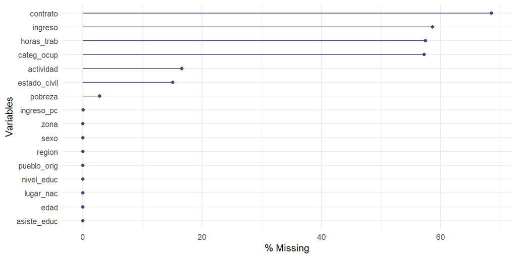

Las variables de trabajo tienen muchos NA porque no aplican a quienes no trabajan.

## NA en operaciones estadísticas

```r
mean(casen_proc$ingreso)                  # NA: no da error, pero tampoco resultado
```

```
[1] NA
```

```r
mean(casen_proc$ingreso, na.rm = TRUE)    # promedio correcto
```

```
[1] 774848
```

Para quedarnos solo con casos completos usamos `drop_na()`:

```r
casen_proc_na <- casen_proc |>
  drop_na()

nrow(casen_proc)
```

```
[1] 5000
```

```r
nrow(casen_proc_na)
```

```
[1] 1511
```

Ojo: `drop_na()` sin argumentos elimina un caso si tiene NA en **cualquier** variable. Con `drop_na(ingreso)` solo se eliminan los NA de `ingreso`.

# Crear categorías

## `if_else()` y `case_when()`

| Función | Cuándo usarla |
| --- | --- |
| `if_else()` | Condición binaria (dos salidas) |
| `case_when()` | Múltiples condiciones |

```r
casen_proc_na <- casen_proc_na |>
  mutate(
    adulto_mayor = if_else(edad >= 60, "Adulto mayor", "No adulto mayor") |>
      factor(levels = c("No adulto mayor", "Adulto mayor")),
    tramo_edad = case_when(
      edad < 18 ~ "Menor de edad",
      edad < 40 ~ "Adulto joven",
      edad < 60 ~ "Adulto",
      .default  = "Adulto mayor"
    ) |>
      factor(levels = c("Menor de edad", "Adulto joven", "Adulto", "Adulto mayor"))
  )
```

`case_when()` evalúa las condiciones en orden: si `edad < 18` ya se cumplió, no revisa las siguientes. Por eso no hace falta escribir `edad >= 18 & edad < 40`.

## `case_when()` con ingresos

```r
casen_proc_na <- casen_proc_na |>
  mutate(
    tramo_ingreso = case_when(
      ingreso < 300000 ~ "Bajo",
      ingreso < 700000 ~ "Medio",
      .default         = "Alto"
    ) |>
      factor(levels = c("Bajo", "Medio", "Alto"),
             ordered = TRUE)
  )

frq(casen_proc_na$tramo_ingreso)
```

```
x <ordinal>
# total N=1511 valid N=1511 mean=2.33 sd=0.61

Value |   N | Raw % | Valid % | Cum. %
--------------------------------------
Bajo  | 110 |  7.28 |    7.28 |   7.28
Medio | 785 | 51.95 |   51.95 |  59.23
Alto  | 616 | 40.77 |   40.77 | 100.00
<NA>  |   0 |  0.00 |    <NA> |   <NA>
```

# Guardar

## Guardar la base procesada

```r
saveRDS(casen_proc_na, "output/casen_proc.rds")

# Para cargarla en la próxima ayudantía:
casen_proc <- readRDS("output/casen_proc.rds")
```

**¿Por qué `.rds` y no `.csv`?**

`.rds` guarda el objeto exactamente como está, incluidos los `factor` y su orden. Un `.csv` los convierte en texto y habría que rehacer el procesamiento.

# Práctica autónoma

## Tu turno (10 min)

Con `casen_proc` (el objeto **con NA**), trabaja con **`zona`**, **`estado_civil`** y **`nivel_educ`**.

1. Explora con `frq()` y `class()`: ¿qué tipo tienen? ¿qué valores?
2. Recodifica `zona` (1 = Urbano, 2 = Rural) como `factor`
3. Recodifica `nivel_educ` (0 = Sin educación … 6 = Superior completa) como `factor` ordenado de menor a mayor
4. Filtra solo personas de zona urbana
5. Calcula el promedio de `ingreso_pc` por zona con `group_by()` y `summarise()`

Consulta `view_df(casen)` si no recuerdas qué significa cada código.

## Resumen de la sesión

| Paso | Función(es) | ¿Para qué? |
| --- | --- | --- |
| Explorar | `view_df()`, `frq()`, `glimpse()` | Ver la base antes de tocarla |
| Encadenar | `\|>` | Escribir pasos en orden de lectura |
| Seleccionar | `select()` | Elegir y renombrar variables |
| Filtrar | `filter()` | Quedarse con ciertos casos |
| Recodificar | `mutate()` + `factor()` | Convertir códigos en categorías |
| NA | `set_na()`, `drop_na()`, `na.rm` | Tratar valores especiales y perdidos |
| Transformar | `if_else()`, `case_when()` | Crear nuevas categorías |
| Guardar | `saveRDS()` | Retomar el trabajo en la AY-3 |

# ¡Nos vemos en la siguiente sesión!